# Praca domowa 2

Ludwik Madej

## Dane

Dane wykorzystane w Pracy domowej 2 opisują wycenę nieruchmości. Każda obserwacja jest pewną nieruchmością, która posiada informacje takie jak powierzchnia, liczba pokoi, liczba łazienek i wiele więcj. Opis wszystkich kolumn w pliku `README.md`.

## Zadanie 1

Jak wygląda rozkład ceny nieruchomości w poszczególnych kodach pocztowych na przestrzeni lat? Rozważamy kody pocztowe, które mają więcej niż 280 posiadłości.

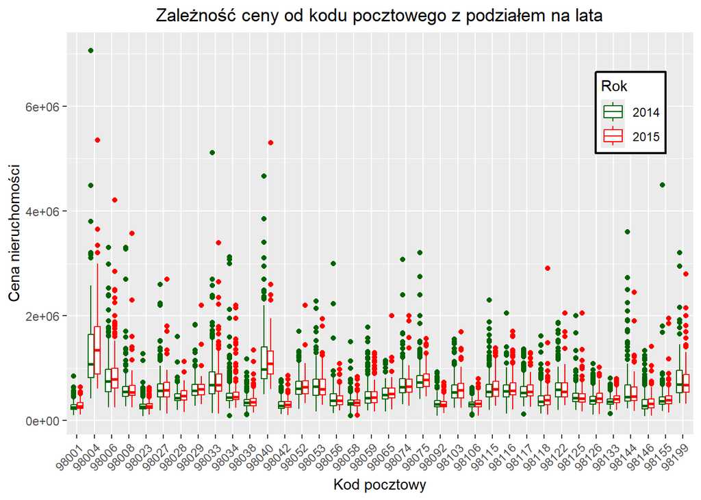

```r
# Tu umieść kod do wygenerowania odpowiedzi do zadania.
df %>%
  mutate(year=as.numeric(str_sub(date,1,4))) %>%
  #distinct(id, .keep_all = TRUE) %>%
  group_by(zipcode) %>%
  filter(n() > 280) %>%
  ungroup() %>%
  ggplot(
    aes(
      x=as.factor(zipcode),
      y=price,
      color=as.factor(year)
    )
  ) +
  geom_boxplot() +
  labs(
    title = "Zależność ceny od kodu pocztowego z podziałem na lata",
    x="Kod pocztowy",
    y="Cena nieruchomości",
    color="Rok"
  ) +
  scale_color_manual(
    values=c("2014"="darkgreen",
             "2015"="red")
                     )+
  theme(axis.text.x = element_text(angle=45, hjust = 1),
        plot.title = element_text(hjust = 0.5),
        legend.position = c(0.9, 0.8),
        legend.background = element_rect(
          color = "black",
          linewidth = 0.8,
          fill = "white"
        ),
        legend.margin = margin(4, 4, 4, 4)
            )
```

**Komentarz:** Możemy zauważyć, że w większości ceny w 2015 roku są niemniejsze niż w roku 2014 (w szczególności mediana jest prawie zawsze niemniejsza), jednak w roku 2015 obserwujemy mniej wartości skrajnie dużych w porówaniu do reszty, a nawet jeśli występują to są zazwyczaj mniejsze niż w roku 2014.

## Zadanie 2

Czy jest różnica w rozkładzie ceny nieruchomości od powierzchni mieszkalnej uwzględniając podział na nieruchomości z piwnicą i bez?

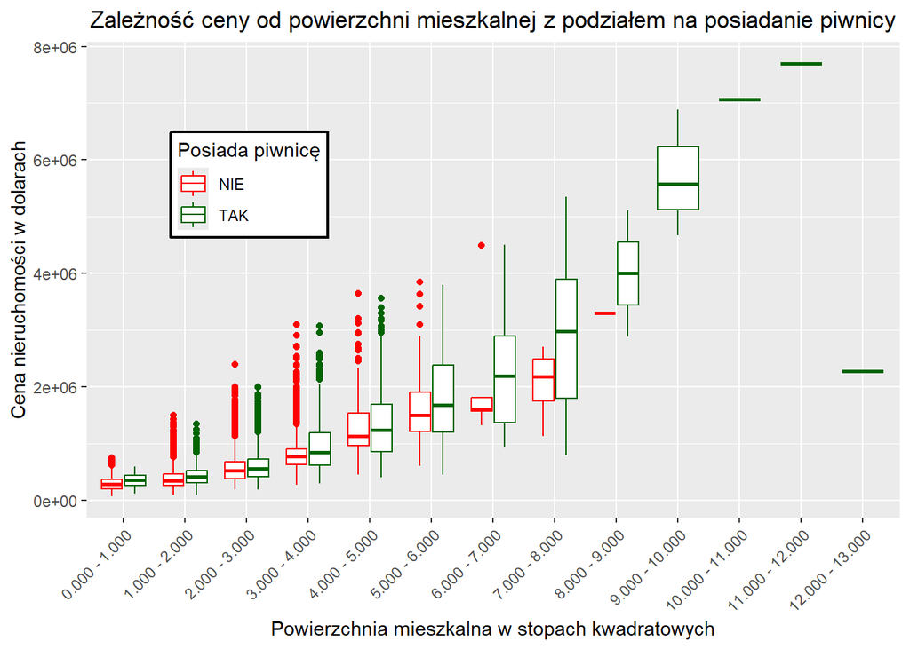

```r
# Tu umieść kod do wygenerowania odpowiedzi do zadania.
df %>%
  mutate(Posiada_piwnice=sqft_basement>0) %>%
  mutate(
    Posiada_piwnice = case_when(
      Posiada_piwnice ~ "TAK",
      TRUE ~ "NIE"
    )
  ) %>%
  ggplot(
    aes(
      x=cut(sqft_living, breaks = seq(0, 14000, by=1000)),
      y=price,
      color=Posiada_piwnice
    )
  ) +
  geom_boxplot() +
  theme(axis.text.x = element_text(angle=45, hjust = 1)) +
  scale_color_manual(
    values=c("TAK"="darkgreen",
             "NIE"="red")
                     ) +
  labs(
    title = "Zależność ceny od powierzchni mieszkalnej z podziałem na posiadanie piwnicy",
    x="Powierzchnia mieszkalna w stopach kwadratowych",
    y="Cena nieruchomości w dolarach",
    color="Posiada piwnicę"
  ) +
  scale_x_discrete(labels=c("0.000 - 1.000", "1.000 - 2.000",
                            "2.000 - 3.000", "3.000 - 4.000",
                            "4.000 - 5.000", "5.000 - 6.000",
                            "6.000 - 7.000", "7.000 - 8.000",
                            "8.000 - 9.000", "9.000 - 10.000",
                            "10.000 - 11.000", "11.000 - 12.000",
                            "12.000 - 13.000", "13.000 - 14.000")
                   ) +
  theme(
    plot.title = element_text(hjust = 0.5),
    legend.position = c(0.2, 0.7),
    legend.background = element_rect(
      color = "black",
      linewidth = 0.8,
      fill = "white"
    ),
    legend.margin = margin(4, 4, 4, 4)
        )
```

**Komentarz:** Widoczna jest tendencja wśród mieszkań do wzrostu ceny wraz z posiadaniem piwnicy (wniosek na podstawie miediany), szczególnie ze wzrostem powierzchni mieszkań oraz mają bardziej rozciągnięty rozkład.Dodatkowo możemy zauważyć, że wśród mieszkań o dużej powierzchni występują głównie mieszkania z piwnicą, a od pewnego momentu (+9000 stop kwadratowych) innych nie zaobserwujemy.

## Zadanie 3

Jaka jest zależność pomiędzy jakością wykończenia nieruchomości a liczbą pięter?

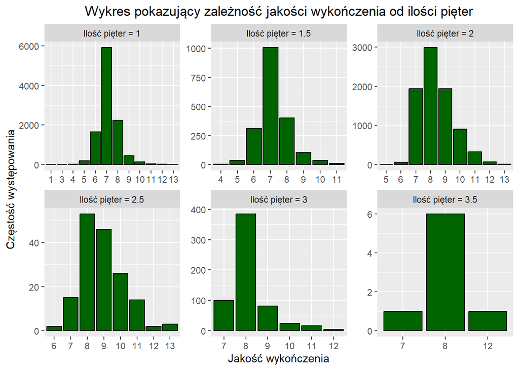

```r
# Tu umieść kod do wygenerowania odpowiedzi do zadania.
# df %>%
#   ggplot(
#     aes(
#       y=grade,
#       x=as.factor(floors)
#     )
#   ) +
#   geom_violin(fill="lightblue") +
#   labs(
#     title = "Wykres zależności wykończenia nieruchomości od liczby pięter",
#     x = "Liczba pięter",
#     y = "Jakość wykończenia"
#   ) +
#   theme(plot.title = element_text(hjust = 0.5)) +
#   scale_y_continuous(
#     breaks = seq(-2, 100, by=1),
#     labels = seq(-2, 100, by=1)
#   )
# tu mielibysmy wykres skrzypcowy, ktory jednak nie niesie tyle informacji co histogram z podzialem na ilość pięter

ggplot(df, aes(x = as.factor(grade))) +
  geom_bar(position = "dodge", color = "black", fill="darkgreen") +
  labs(
    title="Wykres pokazujący zależność jakości wykończenia od ilości pięter",
    x = "Jakość wykończenia",
    y = "Częstość występowania") +
  facet_wrap(~ floors,
             scales="free",
             labeller = as_labeller(
               c(
                  "1" = "Ilość pięter = 1",
                  "1.5" = "Ilość pięter = 1.5",
                  "2" = "Ilość pięter = 2",
                  "2.5" = "Ilość pięter = 2.5",
                  "3" = "Ilość pięter = 3",
                  "3.5" = "Ilość pięter = 3.5"
                )
               )
             ) +
  theme(plot.title = element_text(hjust = 0.5))
```

**Komentarz:** Najgorsze wykończenie posiadają domy jednopiętrowe, których jest najwięcej (ponadto wykres rozkład wykończeń najbardziej przypomina rozkład normalny). Wraz ze wzrostem liczby pięter rośnie standard wykończeń, a rozkład składnia się ku rozkładowy normalnemu, prawostronnie skośnemu.

## Zadanie 4

Jaka jest zależność między powierzchnią mieszkalną nieruchomości a powierzchnią gruntu w podziale na liczbę sypialni?

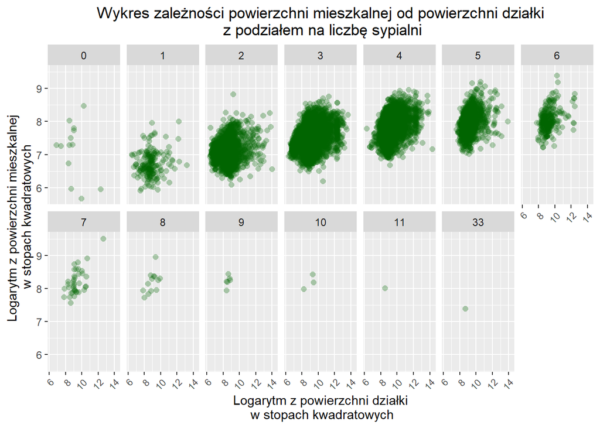

```r
# Tu umieść kod do wygenerowania odpowiedzi do zadania.
df %>%
  ggplot(
    aes(
      y=log(sqft_living),
      x=log(sqft_lot)
    )
  ) +
  geom_point(alpha=0.3, color="darkgreen", shape=16, size=2)+
  facet_wrap(~ bedrooms, nrow = 2) +
  theme(axis.text.x = element_text(angle=45, hjust = 1, size = 8)) +
  labs(
    title = "Wykres zależności powierzchni mieszkalnej od powierzchni działki\n z podziałem na liczbę sypialni",
    x="Logarytm z powierzchni działki\n w stopach kwadratowych",
    y="Logarytm z powierzchni mieszkalnej\n w stopach kwadratowych"
  ) +
  theme(plot.title = element_text(hjust = 0.5))
```

**Komentarz:** (Banalny i oczywisty): im więcej sypialni, tym większa powierzchnia mieszkalna (tendencję wzrostową mamy do liczby sypialni równej 6. Od tego momentu logarytm z powietzchni mieszkalnej oscyluje wokół 8,5) (mamy zbieganie asymptotyczne).

(Trochę ciekawszy): Jeżeli zaaplikujemy operację logarytm na obie osie punkty rozkładają się bardziej równomiernie (możnaby się doszukiwać gdzieniegdzie tendecji wzrostowych, czego absolutnie nie widać na wykresie bez aplikacji logarytmu)

Ciekawe jest również to, że im więcej sypialni, tym rzadziej występują nieruchomości z dużą powierzchnią działki.

## Zadanie 5

Rozważmy tylko nieruchomości, które miały remont. W której dekadzie było najwięcej przeprowadzonych remontów? Czy w poszczególnych dekadach jest porównywalny procent nieruchmości dla każdej wartości miary jakości i wykończenia nieruchomości?

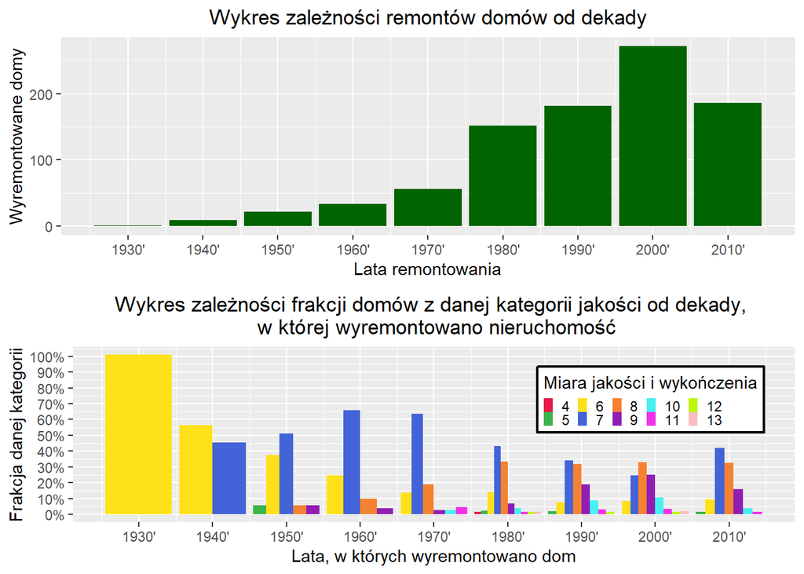

```r
#min(df$yr_renovated[df$yr_renovated != 0]) = 1934
zliczenie_na_dekade <- df %>%
  filter(yr_renovated != 0) %>%
  mutate(decade=(yr_renovated %/% 10)*10) %>%
  group_by(decade) %>%
  summarise(Total_renovated=n())

kategorie_na_dekade <- df %>%
    filter(yr_renovated != 0) %>%
    mutate(decade=(yr_renovated %/% 10)*10) %>%
    group_by(decade, grade) %>%
    summarise(count=n()) %>%
    group_by(decade) %>%
    mutate(count=count/sum(count)*100) %>%
    ungroup() %>%
    mutate(count=count+1)

wykres_zliczen <- zliczenie_na_dekade %>%
  ggplot(
    aes(
      x=decade,
      y=Total_renovated
    )
  ) +
  geom_bar(stat = "identity", fill="darkgreen", position = "dodge") +
  scale_x_continuous(
    breaks = seq(1930, 2010, by = 10),
    labels = paste0(seq(1930, 2010, by = 10),"'")
  ) +
  labs(
    title = "Wykres zależności remontów domów od dekady",
    x="Lata remontowania",
    y="Wyremontowane domy"
  ) +
  theme(plot.title = element_text(hjust = 0.5))

#Wykres kategorii
colors <- c("#E6194B",
            "#3CB44B",
            "#FFE119",
            "#4363D8",
            "#F58231",
            "#911EB4",
            "#46F0F0",
            "#F032E6",
            "#BCF60C",
            "#FABEBE")

wykres_ketegorii <- kategorie_na_dekade %>%
  ggplot(
    aes(
      x=decade,
      y=count,
      fill=as.factor(grade)
    )
  ) +
  geom_bar(stat = "identity", position = "dodge") +
  scale_x_continuous(
    breaks = seq(1930, 2010, by = 10),
    labels = paste0(seq(1930, 2010, by = 10),"'")
  ) +
  scale_y_continuous(
    breaks = seq(0, 100, by=10),
    labels = paste0(seq(0, 100, by=10), "%")
  ) +
  scale_fill_manual(values=colors) +
  labs(
    title = "Wykres zależności frakcji domów z danej kategorii jakości od dekady, \n w której wyremontowano nieruchomość",
    x="Lata, w których wyremontowano dom",
    y="Frakcja danej kategorii",
    fill="Miara jakości i wykończenia"
  ) +
  guides(fill = guide_legend(ncol = 5)) +
  theme(
    plot.title = element_text(hjust = 0.5),
    legend.position = c(0.8, 0.7),
    legend.key.width = unit(0.2, "cm"),
    legend.key.height = unit(0.01, "cm"),
    legend.background = element_rect(
      color = "black",
      linewidth = 0.8,
      fill = "white"
    ),
    legend.margin = margin(4, 4, 4, 4)
        )

grid.arrange(
  wykres_zliczen,
  wykres_ketegorii,
  nrow = 2,
  heights = unit(c(1, 1), "null"))
```

**Komentarz:** Najwięcej remontów przeprowadzono w latach dwutysięcznych. Im później remontowano dom, tym rozkład miary i jakości wykończenia bardziej przypomina rozkład normalny prawoskośny, co oznacza wzrost jakości.

## Zadanie 6

Jak prezentuje się wartość minimalna, średnia i maksymalna ceny nieruchmości w podziele na rok budowy nieruchomości.

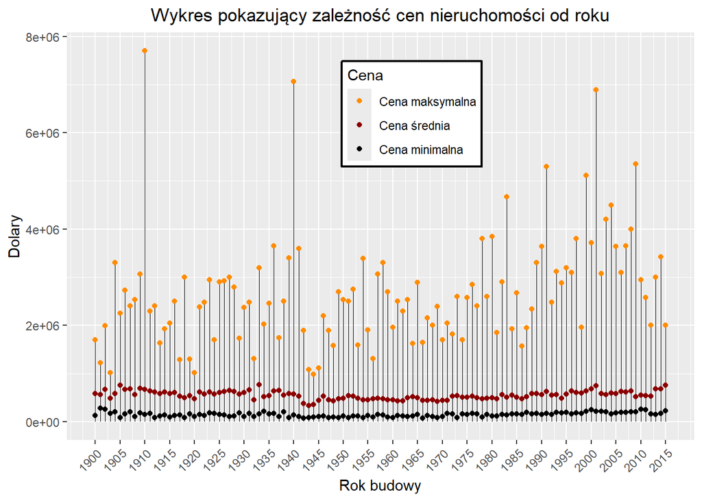

```r
# Tu umieść kod do wygenerowania odpowiedzi do zadania.
df %>%
  group_by(yr_built) %>%
  summarise(
    min_price=min(price),
    mean_price=mean(price),
    max_price=max(price)
  ) %>%
  pivot_longer(
    cols = ends_with("price"),
    names_to = "Type",
    values_to = "Price"
    ) %>%
  # mutate(kolorek=as.numeric(yr_built) %% 2 == 0) %>%
  # mutate(
  #   kolorek=case_when(
  #     kolorek & Type == "min_price" ~ "min_price_1",
  #     kolorek & Type == "mean_price" ~ "mean_price_1",
  #     kolorek & Type == "max_price" ~ "max_price_1",
  #     !kolorek & Type == "min_price" ~ "min_price_2",
  #     !kolorek & Type == "mean_price" ~ "mean_price_2",
  #     TRUE ~ "max_price_2"
  #   )) %>%
  ggplot(
    aes(
      x=yr_built,
      y=Price,
      color=Type
      )
  ) +
  geom_segment(aes(xend = yr_built, yend = 0), linewidth = 0.2, color = "black") + # Linia
  geom_point() +
  labs(
    title = "Wykres pokazujący zależność cen nieruchomości od roku",
    x = "Rok budowy",
    y = "Dolary",
    color="Cena") +
  scale_color_manual(
    values = c(
      "min_price"="black",
      "mean_price"="darkred",
      "max_price"="darkorange"
    ),

    labels=c(
      "min_price"="Cena minimalna",
      "mean_price"="Cena średnia",
      "max_price"="Cena maksymalna"
      )
    )+
  theme(
    plot.title = element_text(hjust = 0.5),
    legend.position = c(0.55, 0.8),
    legend.background = element_rect(
      color = "black",
      linewidth = 0.8,
      fill = "white"),
    legend.margin = margin(4, 4, 4, 4)
        ) +
  scale_x_continuous(
    breaks = seq(1900, 2015, by = 5),
    labels = seq(1900, 2015, by = 5)
  )  +
  theme(axis.text.x = element_text(angle=45, hjust = 1))
```

**Komentarz:** Obserwujemy praktycznie stałe ceny średnie i minimalne na przestrzeni lat. Cena maksymalna gwałtownie się zmienia z roku na rok.